# Predictive Analytics & Forecasting - Discussion #6

Eric Kenney

2023-08-09

## Data

I return to the data set I used in week 3 (the monthly air travel data). I reduce this data down to just air travel internal to the united states. I further reduce the data to a twenty year set and do not include the data in 2020 since that includes massive drop off in air travel due to the COVID-19 pandemic. This creates a 20 year data set I split 80/20 for training and test. I will already used the data I slimmed down and not the raw data for easy ingestion in Github.

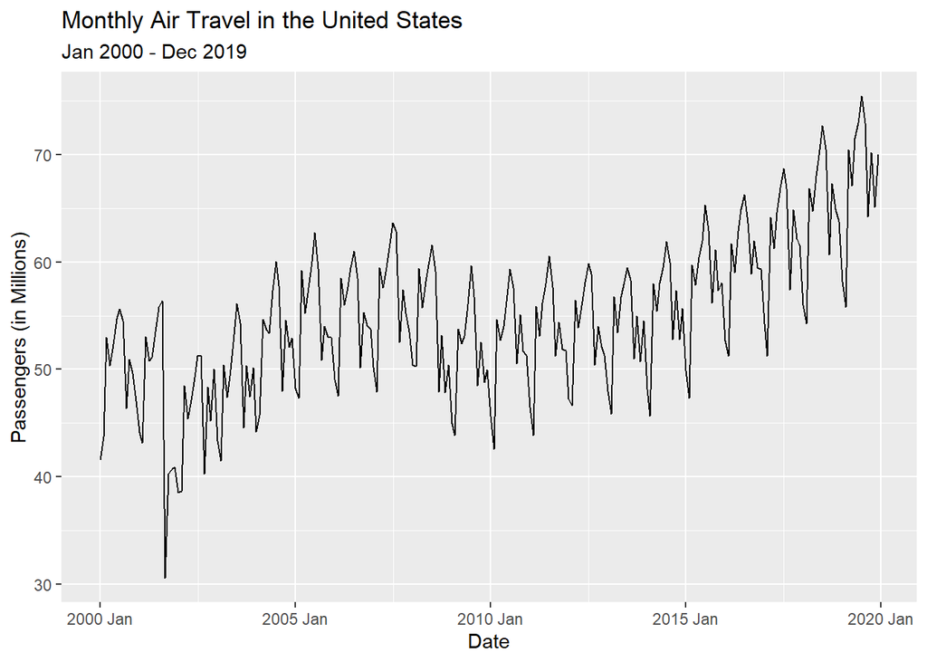

```r
air_travel = read.csv(file.path(path, "air_travel_final.csv")) %>%
  mutate(date = yearmonth(date)) %>%
  as_tsibble(index = date)

# Plot
air_travel %>%
  autoplot(pax/1000000) +
  labs(x = "Date", y = "Passengers (in Millions)",
       title = "Monthly Air Travel in the United States",
       subtitle = "Jan 2000 - Dec 2019")
```

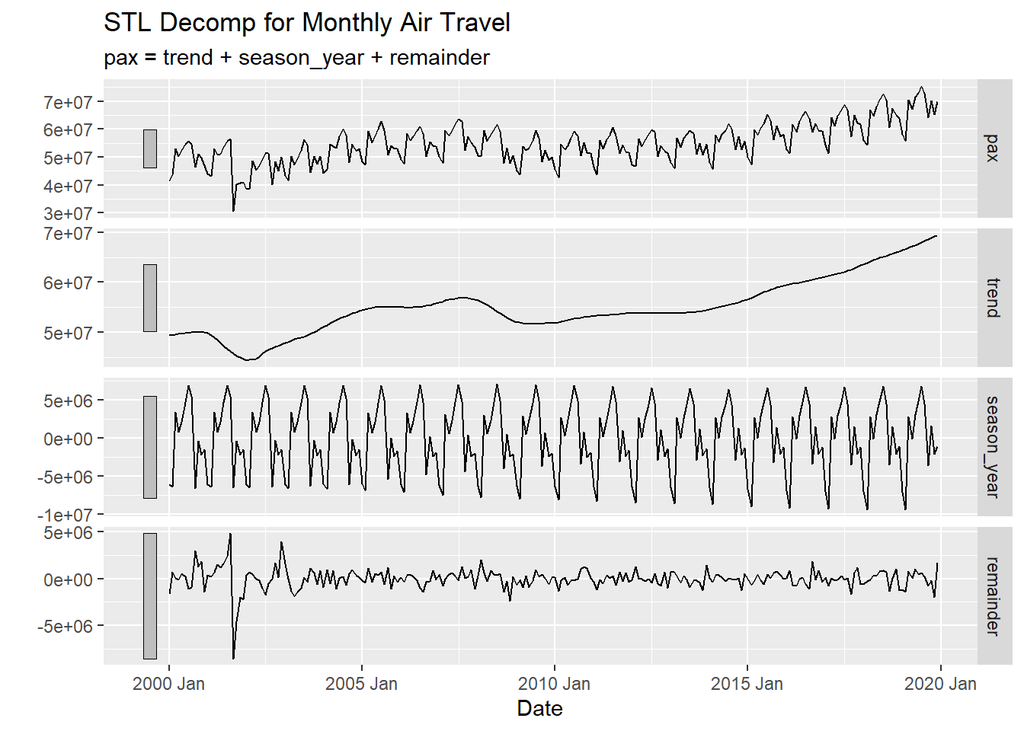

```r
# STL Decomposition
air_travel %>%
  model(STL(pax)) %>%
  components() %>%
  autoplot() +
  labs(x = "Date", y = "",
       title = "STL Decomp for Monthly Air Travel")
```